# Tugas 9

Davina Rachmadyanti

2023-10-24

# Pemodelan Time Series

### Libraries

```r
library(ggplot2)
library(tsibble)
library(tseries)
library(MASS)
library(forecast)
library(TSA)
library(TTR)
library(aTSA)
library(graphics)
```

### Input Data

```r
data<-rio::import("https://raw.githubusercontent.com/reiflection/MPDW/main/Data/Mariah%20Carey%20Listeners.csv")
data
```

```
##           Date Listeners
## 1   10/20/2018  10575647
## 2   10/24/2018  10986651
## 3   10/27/2018  11209520
## 4   10/31/2018  11488186
## 5    11/3/2018  11810538
## 6    11/7/2018  12441565
## 7   11/10/2018  12865722
## 8   11/14/2018  13785415
## 9   11/17/2018  14538505
## 10  11/21/2018  16228228
## 11  11/24/2018  18121486
## 12  11/28/2018  20265477
## 13   12/1/2018  22000203
## 14   12/5/2018  26268832
```

[output cut: 502 more lines]

```r
#Mengambil hanya kolom Close sebagai data baru
listeners <- data$Listeners
listeners
```

```
##   [1] 10575647 10986651 11209520 11488186 11810538 12441565 12865722 13785415
##   [9] 14538505 16228228 18121486 20265477 22000203 26268832 29268174 31984197
##  [17] 33560584 35947894 36792776 42896510 45189364 43445181 41513161 39395632
##  [25] 36971720 34233767 29851238 20219853 12238550 11169173 10741944 10548617
##  [33] 10419399 10341207 10391132 10347898 10273220 10192675 10130574 10093367
##  [41] 10107853 10101563  9986404  9999892 10063410 10097183 10172494 10204979
##  [49] 10215246 10211018 10197366 10150551 10135478 10130232 10092775 10070289
##  [57] 10077760 10070900 10080038 10074883 10064697 10054190 10095145 10195267
##  [65] 10243811 10349975 10414196 10476585 10534211 10533056 10610273 10604404
##  [73] 10615072 10619774 10648358 10665127 10749710 10859722 11011586 11123745
##  [81] 11288793 11433287 11621774 11734541 11873667 11926764 12005646 12048436
##  [89] 12054908 12054908 12080788 12088797 12170871 12158615 12196154 12273703
##  [97] 12363811 12546879 12610003 12815014 12905218 13060617 13163833 13225945
## [105] 13336728 13350719 13432999 13545556 13765124 14518128 15085833 16110280
## [113] 16911697 18192872 19086679 21577275 22571427 26415394 28740387 32539232
```

[output cut: 50 more lines]

```r
#Mengganti tipe data menjadi time series
listeners.ts<-ts(listeners)
```

## Eksplorasi Data

### Plot untuk Seluruh Data

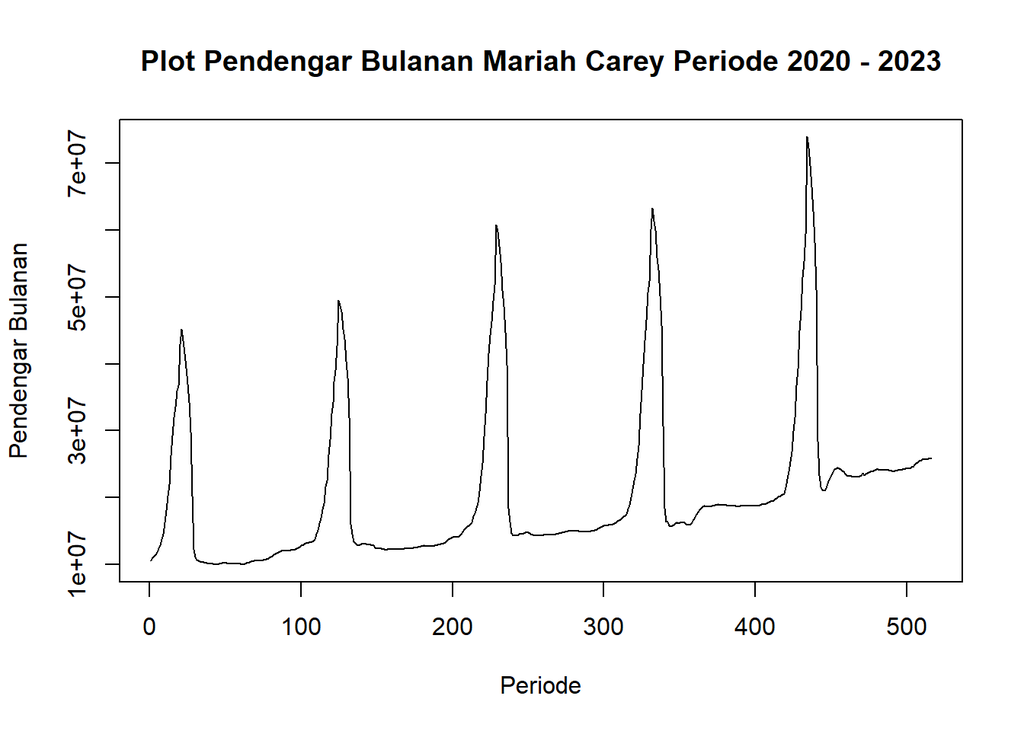

```r
plot.ts(listeners.ts, xlab="Periode", ylab="Pendengar Bulanan", main="Plot Pendengar Bulanan Mariah Carey Periode 2020 - 2023")
```

Plot time series menunjukkan bahwa data memiliki pola trend dan musiman. Kemudian pembagian data train dan data test dilakukan dengan perbandingan 7:3

### Plot Data Train

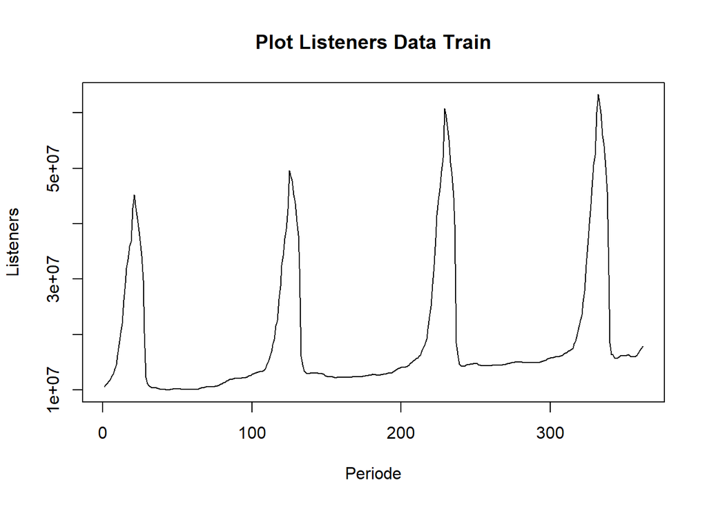

```r
datatrain<-listeners[1:362]
train.ts<-ts(datatrain)
plot.ts(train.ts, lty=1, xlab="Periode", ylab="Listeners", main="Plot Listeners Data Train")
```

Berdasarkan plot data deret waktu pada data latih, terlihat bahwa data cenderung tidak bergerak pada nilai tengah tertentu. Hal ini mengindikasikan bahwa data tidak stasioner dalam rataan.

### Plot Data Test

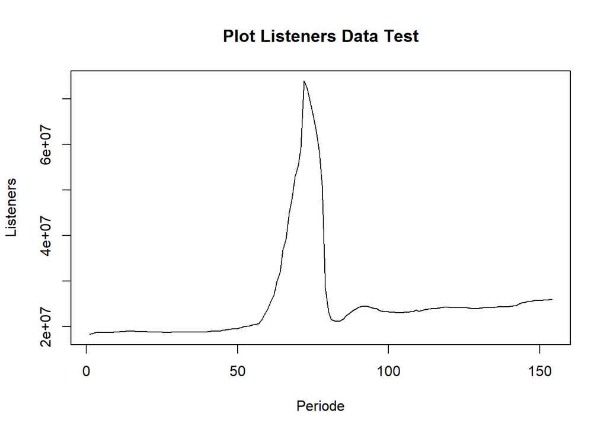

```r
datatest<-listeners[363:516]
test.ts<-ts(datatest)
plot.ts(test.ts, lty=1, xlab="Periode", ylab="Listeners", main="Plot Listeners Data Test")
```

Plot data test mengindikasikan data tidak stasioner dalam rataan maupun ragam. Selanjutnya akan dilihat sifat stasioner data train melalui plot ACF, Uji ADF, dan plot Box-Cox

## Kestasioneran Data

### Plot ACF

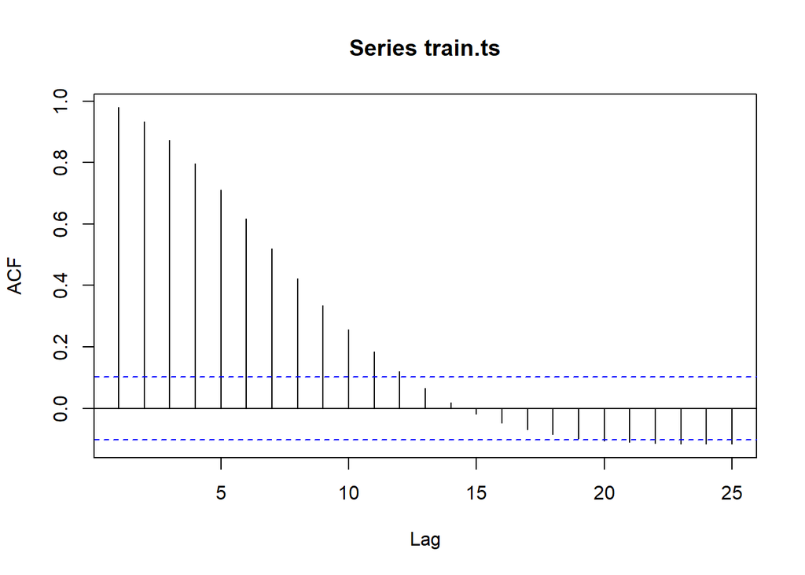

```r
acf(train.ts)
```

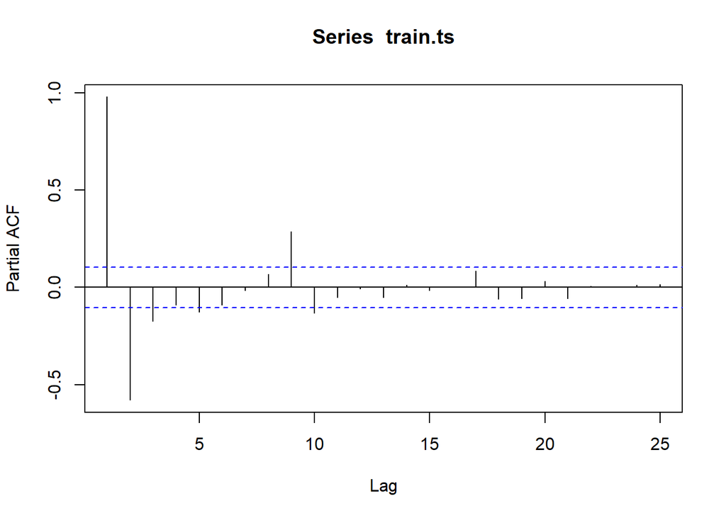

```r
pacf(train.ts)
```

Plot ACF di atas menampilkan bahwa data menurun secara perlahan, artinya data diindikasi tidak stasioner dalam rataan.

### Uji ADF

H0: Data tidak stasioner dalam rataan

H1: Data stasioner dalam rataan

```r
tseries::adf.test(train.ts)
```

```
##
##  Augmented Dickey-Fuller Test
##
## data:  train.ts
## Dickey-Fuller = -4.8511, Lag order = 7, p-value = 0.01
## alternative hypothesis: stationary
```

Berdasarkan hasil uji ADF, diperoleh p-value sebesar 0.01 < 0.05. Hal ini menunjukkan keputusan tolak H0, artinya data stasioner dalam rataan.

### Plot Box-Cox

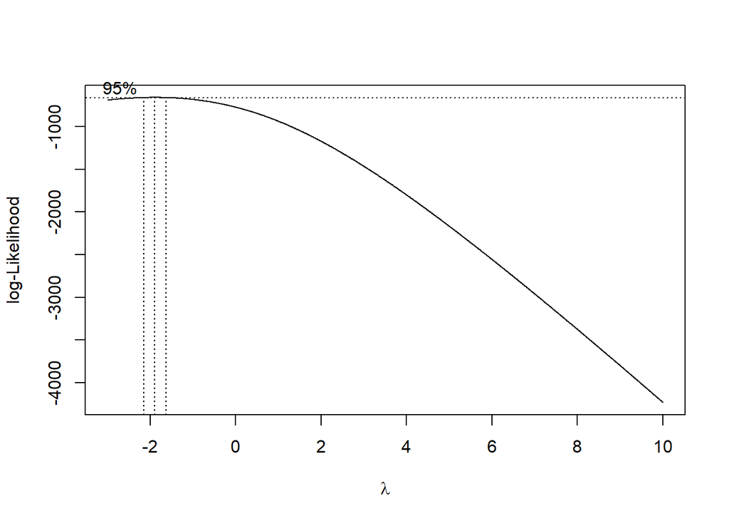

```r
index <- seq(1:362)
bc = boxcox(train.ts~index, lambda = seq(-3,10,by=0.01))
```

```r
#Nilai Rounded Lambda
lambda <- bc$x[which.max(bc$y)]
lambda
```

```
## [1] -1.89
```

```r
#SK
bc$x[bc$y > max(bc$y) - 1/2 * qchisq(.95,1)]
```

```
##  [1] -2.15 -2.14 -2.13 -2.12 -2.11 -2.10 -2.09 -2.08 -2.07 -2.06 -2.05 -2.04
## [13] -2.03 -2.02 -2.01 -2.00 -1.99 -1.98 -1.97 -1.96 -1.95 -1.94 -1.93 -1.92
## [25] -1.91 -1.90 -1.89 -1.88 -1.87 -1.86 -1.85 -1.84 -1.83 -1.82 -1.81 -1.80
## [37] -1.79 -1.78 -1.77 -1.76 -1.75 -1.74 -1.73 -1.72 -1.71 -1.70 -1.69 -1.68
## [49] -1.67 -1.66 -1.65 -1.64 -1.63
```

Plot Boxcox menunjukkan nilai lambda (λ) optimum sebesar -1.89. Pada selang kepercayaan 95% nilai memiliki batas bawah -2.15 dan batas atas -1.63. Selang tersebut tidak memuat nilai satu sehingga dapat dikatakan bahwa data yang digunakan tidak stasioner dalam ragam.

## Penanganan Stasioner dalam Ragam

### Transformasi 1/x^2

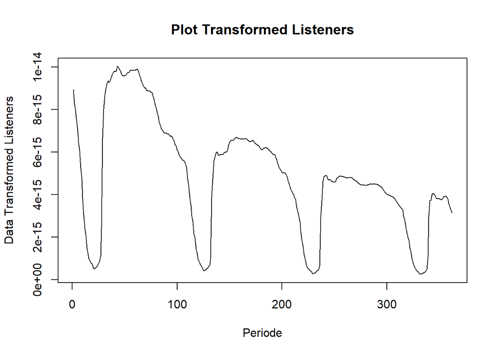

```r
# Melakukan transformasi 1/x^2
train.transformed = 1/(train.ts^2)

plot.ts(train.transformed, lty=1, xlab="Periode", ylab="Data Transformed Listeners", main="Plot Transformed Listeners")
```

### Plot Box-Cox

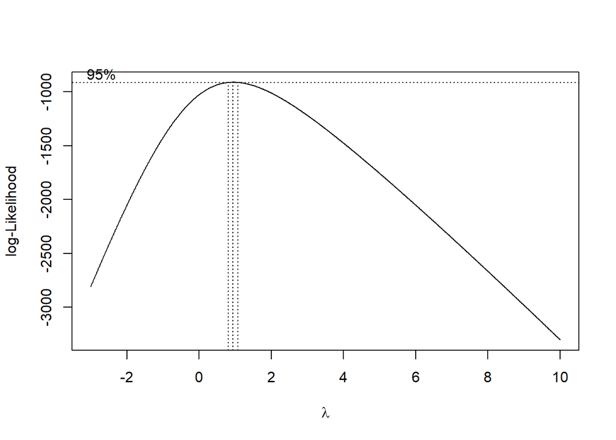

```r
index <- seq(1:362)
bct = boxcox(train.transformed~index, lambda = seq(-3,10,by=0.01))
```

```r
#Nilai Rounded Lambda
lambdabaru <- bct$x[which.max(bct$y)]
lambdabaru
```

```
## [1] 0.94
```

```r
#SK
bct$x[bct$y > max(bct$y) - 1/2 * qchisq(.95,1)]
```

```
##  [1] 0.82 0.83 0.84 0.85 0.86 0.87 0.88 0.89 0.90 0.91 0.92 0.93 0.94 0.95 0.96
## [16] 0.97 0.98 0.99 1.00 1.01 1.02 1.03 1.04 1.05 1.06 1.07
```

Plot Boxcox menunjukkan nilai lambda (λ) optimum sebesar 0.94. Pada selang kepercayaan 95% nilai memiliki batas bawah 0.82 dan batas atas 1.07. Selang tersebut memuat nilai satu sehingga dapat dikatakan bahwa data yang digunakan stasioner dalam ragam.

## Penanganan Stasioner dalam Rataan

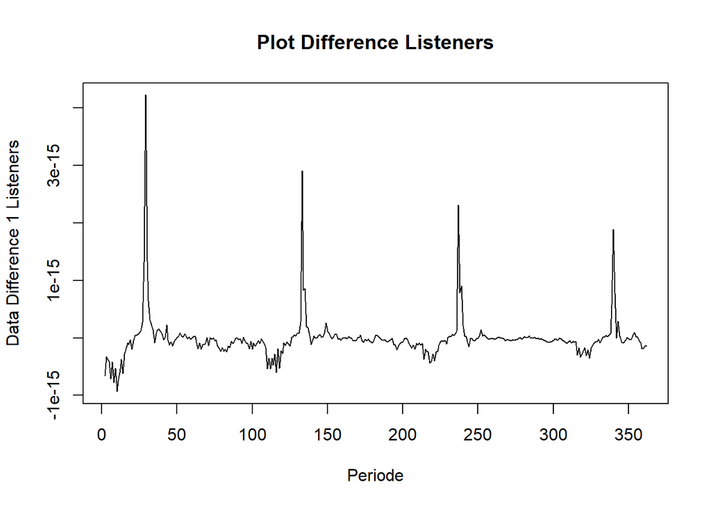

```r
train.diff<-diff(train.transformed,differences = 1)
plot.ts(train.diff, lty=1, xlab="Periode", ylab="Data Difference 1 Listeners", main="Plot Difference Listeners")
```

### Plot ACF

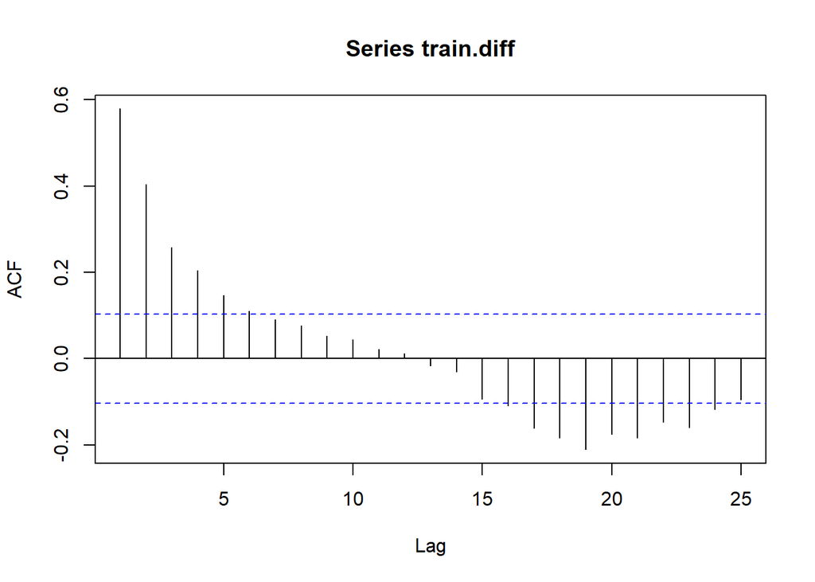

```r
acf(train.diff)
```

### Uji ADF

H0: Data tidak stasioner dalam rataan

H1: Data stasioner dalam rataan

```r
tseries::adf.test(train.diff)
```

```
##
##  Augmented Dickey-Fuller Test
##
## data:  train.diff
## Dickey-Fuller = -5.3158, Lag order = 7, p-value = 0.01
## alternative hypothesis: stationary
```

Berdasarkan hasil uji ADF, diperoleh p-value sebesar 0.01 < 0.05. Hal ini menunjukkan keputusan tolak H0, artinya data stasioner dalam rataan.

## Identifikasi Model

### Plot ACF

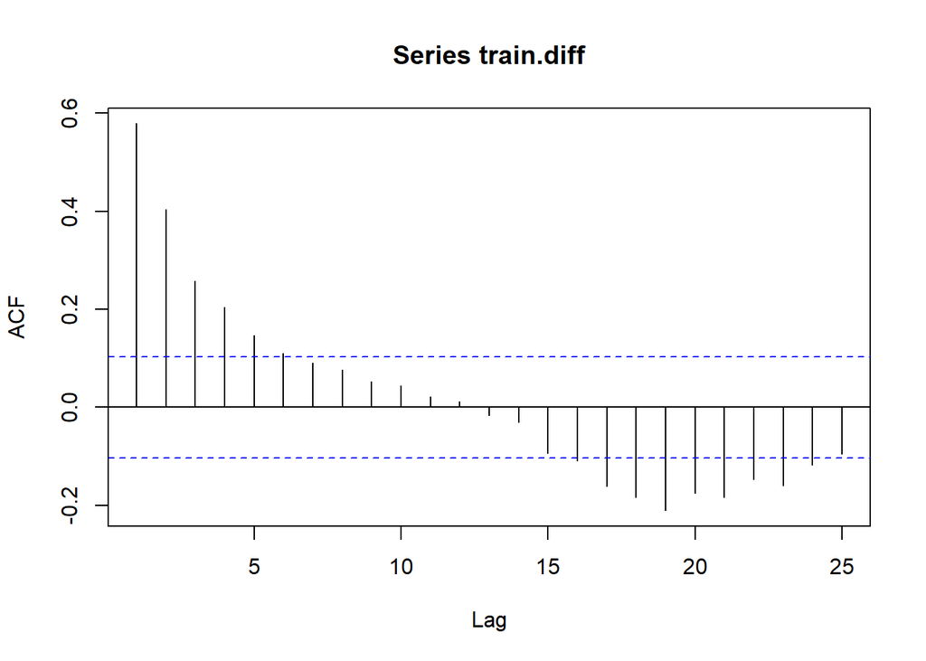

```r
acf(train.diff)
```

Identifikasi model menggunakan plot ACF tidak menampilkan data cuts off di lag mana pun.

### Plot PACF

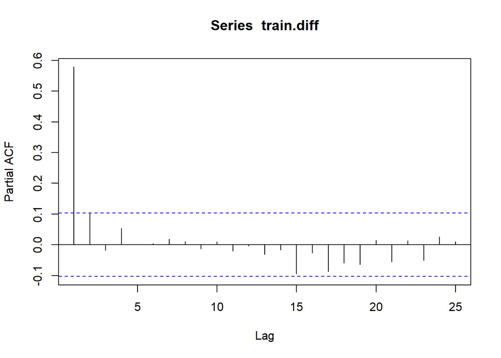

```r
pacf(train.diff)
```

Identifikasi model menggunakan plot PACF menampilkan data cuts off di lag 1.

### Plot EACF

```r
eacf(train.diff)
```

```
## AR/MA
##   0 1 2 3 4 5 6 7 8 9 10 11 12 13
## 0 x x x x x x o o o o o  o  o  o
## 1 x o o o o o o o o o o  o  o  o
## 2 x o o o o o o o o o o  o  o  o
## 3 x x o o o o o o o o o  o  o  o
## 4 o o x o o o o o o o o  o  o  o
## 5 x o x x o o o o o o o  o  o  o
## 6 x x x x o o o o o o o  o  o  o
## 7 x x x x x o o o o o o  o  o  o
```

Identifikasi model menggunakan plot menunjukkan model tentatif yang terbentuk adalah ARIMA(1,1,1), ARIMA(2,1,1), dan ARIMA(3,1,2)

## Pendugaan Parameter Model Tentatif

### ARIMA(1,1,1)

```r
model1.da=Arima(train.diff, order=c(1,1,1),method="ML")
summary(model1.da) #AIC=-24667.58
```

```
## Series: train.diff
## ARIMA(1,1,1)
##
## Coefficients:
##          ar1      ma1
##       0.5860  -1.0000
## s.e.  0.0432   0.0079
##
## sigma^2 = 9.975e-32:  log likelihood = 12336.79
## AIC=-24667.58   AICc=-24667.51   BIC=-24655.92
##
## Training set error measures:
##                        ME         RMSE          MAE MPE MAPE      MASE
## Training set 1.870401e-17 3.145113e-16 1.058498e-16 NaN  Inf 0.8675718
##                     ACF1
## Training set -0.06450486
```

```r
lmtest::coeftest(model1.da) #seluruh parameter signifikan
```

```
##
## z test of coefficients:
##
##       Estimate Std. Error  z value  Pr(>|z|)
## ar1  0.5859591  0.0431541   13.578 < 2.2e-16 ***
## ma1 -0.9999995  0.0078807 -126.892 < 2.2e-16 ***
## ---
## Signif. codes:  0 '***' 0.001 '**' 0.01 '*' 0.05 '.' 0.1 ' ' 1
```

Diperoleh nilai AIC sebesar -24667.58 dengan seluruh parameter signifikan

### ARIMA(2,1,1)

```r
model2.da=Arima(train.diff, order=c(2,1,1),method="ML")
summary(model2.da) #AIC=-24669.7
```

```
## Series: train.diff
## ARIMA(2,1,1)
##
## Coefficients:
##          ar1     ar2      ma1
##       0.5243  0.1070  -1.0000
## s.e.  0.0525  0.0526   0.0077
##
## sigma^2 = 9.894e-32:  log likelihood = 12338.85
## AIC=-24669.7   AICc=-24669.59   BIC=-24654.15
##
## Training set error measures:
##                        ME         RMSE          MAE MPE MAPE      MASE
## Training set 1.738106e-17 3.128065e-16 1.027867e-16 NaN  Inf 0.8424655
##                       ACF1
## Training set -0.0002308923
```

```r
lmtest::coeftest(model2.da) #seluruh parameter signifikan
```

```
##
## z test of coefficients:
##
##       Estimate Std. Error   z value Pr(>|z|)
## ar1  0.5243226  0.0525363    9.9802  < 2e-16 ***
## ar2  0.1069521  0.0525676    2.0346  0.04189 *
## ma1 -0.9999948  0.0076881 -130.0696  < 2e-16 ***
## ---
## Signif. codes:  0 '***' 0.001 '**' 0.01 '*' 0.05 '.' 0.1 ' ' 1
```

Diperoleh nilai AIC sebesar -24669.7 dengan seluruh parameter signifikan

### ARIMA(3,1,2)

```r
model3.da=Arima(train.diff, order=c(3,1,2),method="ML")
summary(model3.da) #AIC=-24666.17
```

```
## Series: train.diff
## ARIMA(3,1,2)
##
## Coefficients:
##           ar1     ar2     ar3      ma1      ma2
##       -0.0033  0.4013  0.0260  -0.4682  -0.5318
## s.e.   0.9145  0.4776  0.1162   0.9142   0.9142
##
## sigma^2 = 9.936e-32:  log likelihood = 12339.09
## AIC=-24666.17   AICc=-24665.94   BIC=-24642.86
##
## Training set error measures:
##                        ME        RMSE          MAE MPE MAPE      MASE
## Training set 1.754223e-17 3.12582e-16 1.021156e-16 NaN  Inf 0.8369656
##                      ACF1
## Training set -0.002952295
```

```r
lmtest::coeftest(model3.da) #tidak ada parameter yang signifikan
```

```
##
## z test of coefficients:
##
##       Estimate Std. Error z value Pr(>|z|)
## ar1 -0.0032678  0.9145082 -0.0036   0.9971
## ar2  0.4012666  0.4775808  0.8402   0.4008
## ar3  0.0259850  0.1162171  0.2236   0.8231
## ma1 -0.4682200  0.9142412 -0.5121   0.6086
## ma2 -0.5317715  0.9142008 -0.5817   0.5608
```

Diperoleh nilai AIC sebesar -24666.17 dengan tidak ada parameter yang signifikan

Pendugaan parameter beberapa model tentatif di atas, menunjukkan nilai AIC terkecil dimiliki oleh model ARIMA(2,1,1) dengan seluruh parameter signifikan, sehingga model yang dipilih adalah model ARIMA(2,1,1).

## Analisis Sisaan

### Eksplorasi Sisaan

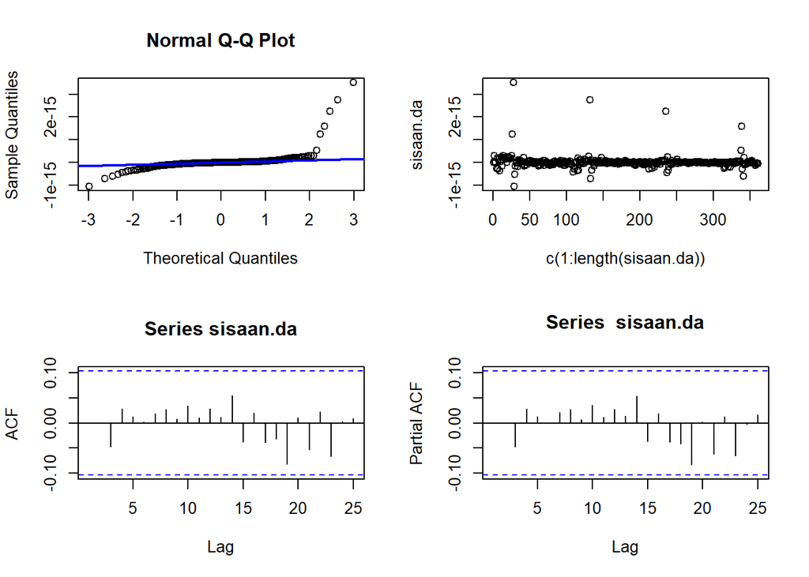

```r
#Eksplorasi
sisaan.da <- model2.da$residuals
par(mfrow=c(2,2))
qqnorm(sisaan.da)
qqline(sisaan.da, col = "blue", lwd = 2)
plot(c(1:length(sisaan.da)),sisaan.da)
acf(sisaan.da)
pacf(sisaan.da)
```

Berdasarkan QQ plot, secara eksplorasi ditunjukkan sisaan tidak menyebar normal ditandai dengan titik titik yang cenderung tidak mengikuti garis 45 derajat. Kemudian dapat dilihat juga lebar pita sisaan yang cenderung tidak sama menandakan bahwa sisaan memiliki ragam yang heterogen. Plot ACF dan PACF sisaan ARIMA(2,1,1) juga tidak signifikan pada 25 lag awal yang menandakan saling bebas. Kondisi ini akan diuji lebih lanjut dengan uji formal.

### Uji Formal

#### Uji Normalitas Jarque Bera

H0: Sisaan menyebar normal

H1: Sisaan tidak menyebar normal

```r
#1) Sisaan Menyebar Normal
tseries::jarque.bera.test(sisaan.da)  #tolak H0 > sisaan tidak menyebar normal
```

```
##
##  Jarque Bera Test
##
## data:  sisaan.da
## X-squared = 71281, df = 2, p-value < 2.2e-16
```

#### Uji Autokorelasi Ljung-Box

H0: Sisaan saling bebas

H1: Sisaan tidak tidak saling bebas

```r
#2) Sisaan saling bebas/tidak ada autokorelasi
Box.test(sisaan.da, type = "Ljung")  #tak tolak H0 > sisaan saling bebas
```

```
##
##  Box-Ljung test
##
## data:  sisaan.da
## X-squared = 1.9406e-05, df = 1, p-value = 0.9965
```

Berdasarkan hasil uji di atas, diperoleh p-value sebesar 0.9965 > 0.05 sehingga menunjukkan keputusan terima H0, artinya sisaan saling bebas/ tidak ada autokorelasi.

#### Uji Homogenitas Sisaan Ljung Box

H0: Ragam sisaan homogen

H1: Ragam sisaan tidak homogen

```r
#3) Sisaan homogen
Box.test((sisaan.da)^2, type = "Ljung")  #tolak H0 > sisaan tidak homogen
```

```
##
##  Box-Ljung test
##
## data:  (sisaan.da)^2
## X-squared = 8.201, df = 1, p-value = 0.004187
```

#### Uji Nilai harapan sisaan = 0

H0: nilai tengah sisaan sama dengan 0

H1: nilai tengah sisaan tidak sama dengan 0

```r
#4) Nilai tengah sisaan sama dengan nol
t.test(sisaan.da, mu = 0, conf.level = 0.95)  #tak tolak h0 > nilai tengah sisaan sama dengan 0
```

```
##
##  One Sample t-test
##
## data:  sisaan.da
## t = 1.0559, df = 360, p-value = 0.2917
## alternative hypothesis: true mean is not equal to 0
## 95 percent confidence interval:
##  -1.499050e-17  4.975263e-17
## sample estimates:
##    mean of x
## 1.738106e-17
```

Berdasarkan hasil uji di atas, diperoleh p-value sebesar 0.292 > 0.05 sehingga menunjukkan keputusan terima H0, artinya nilai tengah sisaan sama dengan nol.

## Overfitting

Tahapan selanjutnya adalah overfitting dilakukan dengan menaikkan orde AR(p) dan MA(q) dari model ARIMA(2,1,1) untuk melihat apakah terdapat model lain yang lebih baik dari model saat ini. Kandidat model overfitting adalah ARIMA(2,1,2) dan ARIMA(3,1,1).

### ARIMA(2,1,2)

```r
model.overfit1=Arima(train.diff, order=c(2,1,2),method="ML")
summary(model.overfit1) #-24667.89
```

```
## Series: train.diff
## ARIMA(2,1,2)
##
## Coefficients:
##           ar1     ar2      ma1      ma2
##       -0.0153  0.4107  -0.4474  -0.5525
## s.e.   0.3995  0.2117   0.4217   0.4216
##
## sigma^2 = 9.914e-32:  log likelihood = 12338.95
## AIC=-24667.89   AICc=-24667.72   BIC=-24648.46
##
## Training set error measures:
##                        ME         RMSE          MAE MPE MAPE      MASE
## Training set 1.790424e-17 3.126833e-16 1.024949e-16 NaN  Inf 0.8400743
##                     ACF1
## Training set -0.01109137
```

```r
lmtest::coeftest(model.overfit1) #seluruh parameter tidak signifikan
```

```
##
## z test of coefficients:
##
##     Estimate Std. Error z value Pr(>|z|)
## ar1 -0.01534    0.39951 -0.0384  0.96937
## ar2  0.41067    0.21166  1.9403  0.05235 .
## ma1 -0.44744    0.42168 -1.0611  0.28865
## ma2 -0.55248    0.42158 -1.3105  0.19003
## ---
## Signif. codes:  0 '***' 0.001 '**' 0.01 '*' 0.05 '.' 0.1 ' ' 1
```

### ARIMA(3,1,1)

```r
model.overfit2=Arima(train.diff, order=c(3,1,1),method="ML")
summary(model.overfit2) #-24667.77
```

```
## Series: train.diff
## ARIMA(3,1,1)
##
## Coefficients:
##          ar1     ar2      ar3      ma1
##       0.5257  0.1141  -0.0138  -1.0000
## s.e.  0.0528  0.0592   0.0528   0.0077
##
## sigma^2 = 9.92e-32:  log likelihood = 12338.88
## AIC=-24667.77   AICc=-24667.6   BIC=-24648.34
##
## Training set error measures:
##                        ME         RMSE          MAE MPE MAPE      MASE
## Training set 1.751645e-17 3.127641e-16 1.023362e-16 NaN  Inf 0.8387734
##                       ACF1
## Training set -0.0009002409
```

```r
lmtest::coeftest(model.overfit2) #ar2,ar3 tidak signifikan
```

```
##
## z test of coefficients:
##
##       Estimate Std. Error   z value Pr(>|z|)
## ar1  0.5256779  0.0527861    9.9586  < 2e-16 ***
## ar2  0.1140765  0.0592258    1.9261  0.05409 .
## ar3 -0.0137579  0.0527855   -0.2606  0.79437
## ma1 -0.9999994  0.0077089 -129.7205  < 2e-16 ***
## ---
## Signif. codes:  0 '***' 0.001 '**' 0.01 '*' 0.05 '.' 0.1 ' ' 1
```

Berdasarkan percobaan overfitting di atas, dipilih model awal yaitu, **ARIMA(2,1,1)**

## Peramalan

Peramalan dilakukan untuk 30 periode ke depan

```r
#---FORECAST---#
ramalan.da <- forecast::forecast(model2.da, h = 30)
ramalan.da
```

```
##     Point Forecast         Lo 80        Hi 80         Lo 95        Hi 95
## 363  -9.389035e-17 -4.975584e-16 3.097777e-16 -7.112473e-16 5.234666e-16
## 364  -7.123582e-17 -5.275377e-16 3.850661e-16 -7.690893e-16 6.266177e-16
## 365  -5.476065e-17 -5.369339e-16 4.274126e-16 -7.921810e-16 6.826597e-16
## 366  -4.369940e-17 -5.372882e-16 4.498894e-16 -7.985784e-16 7.111796e-16
## 367  -3.613768e-17 -5.351071e-16 4.628317e-16 -7.992455e-16 7.269701e-16
## 368  -3.098988e-17 -5.325249e-16 4.705451e-16 -7.980214e-16 7.360417e-16
## 369  -2.748203e-17 -5.302661e-16 4.753020e-16 -7.964239e-16 7.414598e-16
## 370  -2.509221e-17 -5.284973e-16 4.783129e-16 -7.949838e-16 7.447994e-16
## 371  -2.346401e-17 -5.271859e-16 4.802579e-16 -7.938402e-16 7.469122e-16
## 372  -2.235471e-17 -5.262432e-16 4.815338e-16 -7.929857e-16 7.482763e-16
## 373  -2.159894e-17 -5.255782e-16 4.823803e-16 -7.923687e-16 7.491708e-16
## 374  -2.108403e-17 -5.251145e-16 4.829464e-16 -7.919320e-16 7.497640e-16
## 375  -2.073322e-17 -5.247936e-16 4.833272e-16 -7.916271e-16 7.501606e-16
## 376  -2.049421e-17 -5.245727e-16 4.835843e-16 -7.914158e-16 7.504274e-16
```

[output cut: 16 more lines]

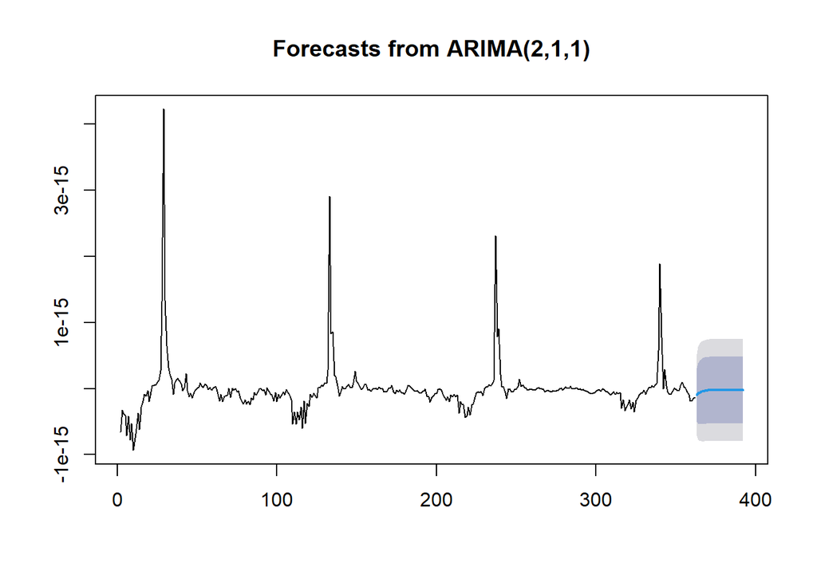

```r
data.ramalan.da <- ramalan.da$mean
plot(ramalan.da)
```

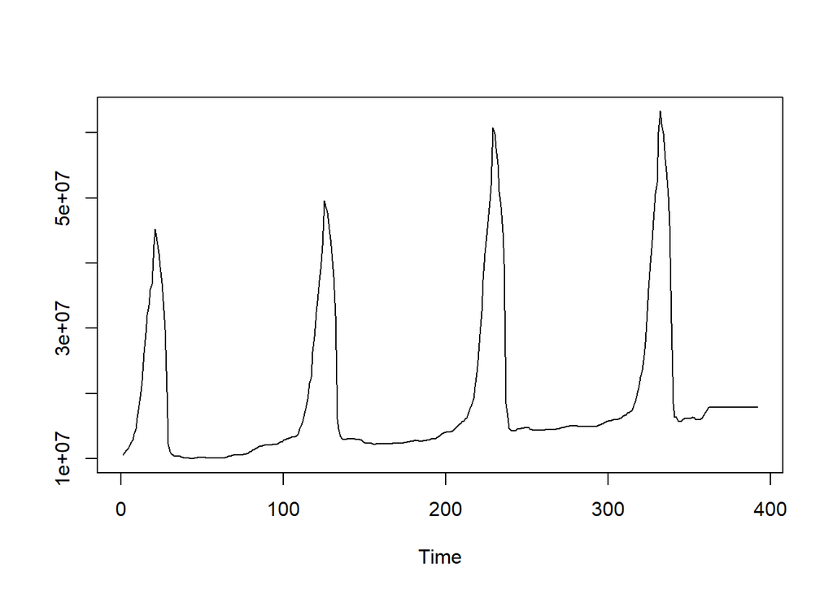

```r
pt_1 <- train.ts[362] #nilai akhir data latih
hasil.forc.Diff <- data.ramalan.da
hasil <- diffinv(hasil.forc.Diff, differences = 1) + pt_1

#has.1 sama hasilnta dengan: cumsum(c(pt_1,hasil.forc.Diff))
ts.plot(train.ts,hasil)
```

```r
perbandingan.da<-matrix(data=c(head(test.ts, n=30), hasil[-1]),
                     nrow = 30, ncol = 2)
colnames(perbandingan.da)<-c("Aktual","Hasil Forecast")
perbandingan.da
```

```
##         Aktual Hasil Forecast
##  [1,] 18249727       17846221
##  [2,] 18478722       17846221
##  [3,] 18658646       17846221
##  [4,] 18776598       17846221
##  [5,] 18699521       17846221
##  [6,] 18680683       17846221
##  [7,] 18696191       17846221
##  [8,] 18696191       17846221
##  [9,] 18783690       17846221
## [10,] 18783690       17846221
## [11,] 18849435       17846221
## [12,] 18849435       17846221
## [13,] 18968314       17846221
## [14,] 18944194       17846221
```

[output cut: 16 more lines]

```r
accuracy(ts(hasil[-1]), head(test.ts, n=30))
```

```
##                ME     RMSE      MAE      MPE     MAPE     ACF1 Theil's U
## Test set 915735.1 925879.9 915735.1 4.875694 4.875694 0.635584  13.05071
```

**MAPE 4.87%**